# Lab 3: Covid-19

Ecosystem Science and Sustainability 330

Author

Natasha Zizic

```r
library(tidyverse)
library(flextable)
library(zoo)
```

Question 1:

```r
url = 'https://raw.githubusercontent.com/nytimes/covid-19-data/master/us-counties.csv'
covid = read.csv(url)
head(covid, 5)
```

```
        date    county      state  fips cases deaths
1 2020-01-21 Snohomish Washington 53061     1      0
2 2020-01-22 Snohomish Washington 53061     1      0
3 2020-01-23 Snohomish Washington 53061     1      0
4 2020-01-24      Cook   Illinois 17031     1      0
5 2020-01-24 Snohomish Washington 53061     1      0
```

How does easy access to historical and real-time environmental data shape our understanding of climate trends, resource management, and public health? What happens when this data disappears or becomes inaccessible?

Easy access to historical and current data has dramatically improved our knowledge of these topics. Since we are able to see the data over time, it is much easier to understand how things have changed over time as well as the current state of things. Unfortunately, we are so reliant on this data that when it becomes inaccessible, it can have negative consequences. For example, when data is not regularly updated, but people are expecting updated information, it is much more likely that there will be a spread of misinformation.

Question 2:

```r
my.date <- as.Date("2022-02-01")
my.state <- "Colorado"
```

```r
co_data <- covid |>
  filter(state == my.state)|>
  group_by(county) |>
  arrange(date) |>
  mutate(new_cases = cases - lag(cases, default = first(cases)),
         new_deaths = deaths - lag(deaths, default = first(deaths))) |>
  ungroup()
```

```r
latest_data <- co_data |>
  filter(date == my.date)
```

```r
top5_cumulative <- latest_data |>
  arrange(desc(cases)) |>
  slice(1:5) |>
  select(county, cases)

top5_new_cases <- latest_data |>
  arrange(desc(new_cases)) |>
  slice(1:5) |>
  select(county, new_cases)
```

```r
safe_counties <- latest_data |>
  filter(new_cases < 100) |>
  select(county)
```

```r
total_new_cases <- sum(latest_data$new_cases, na.rm = TRUE)
total_cumulative_cases <- sum(latest_data$cases, na.rm = TRUE)
num_safe_counties <- nrow(safe_counties)
```

```r
knitr::kable(top5_cumulative, caption = "Top 5 Counties by Cumulative Cases")
```

Top 5 Counties by Cumulative Cases

| county | cases |
| --- | --- |
| El Paso | 170673 |
| Denver | 159022 |
| Arapahoe | 144255 |
| Adams | 126768 |
| Jefferson | 113240 |

```r
knitr::kable(top5_new_cases, caption = "Top 5 Counties by New Cases")
```

Top 5 Counties by New Cases

| county | new_cases |
| --- | --- |
| El Paso | 630 |
| Arapahoe | 401 |
| Denver | 389 |
| Adams | 326 |
| Jefferson | 291 |

```r
knitr::kable(safe_counties, caption = "Counties Considered Safe")
```

Counties Considered Safe

| county |
| --- |
| Alamosa |
| Archuleta |
| Baca |
| Bent |
| Broomfield |
| Chaffee |
| Cheyenne |
| Clear Creek |
| Conejos |
| Costilla |
| Crowley |
| Custer |
| Delta |
| Dolores |
| Eagle |
| Elbert |
| Fremont |
| Garfield |
| Gilpin |
| Grand |
| Gunnison |
| Hinsdale |
| Huerfano |
| Jackson |
| Kiowa |
| Kit Carson |
| La Plata |
| Lake |
| Las Animas |
| Lincoln |
| Logan |
| Mineral |
| Moffat |
| Montezuma |
| Montrose |
| Morgan |
| Otero |
| Ouray |
| Park |
| Phillips |
| Pitkin |
| Prowers |
| Rio Blanco |
| Rio Grande |
| Routt |
| Saguache |
| San Juan |
| San Miguel |
| Sedgwick |
| Summit |
| Teller |
| Washington |
| Yuma |

Question 3:

```r
pop_url <- 'https://www2.census.gov/programs-surveys/popest/datasets/2020-2023/counties/totals/co-est2023-alldata.csv'
pop_data <- read_csv(pop_url)
head(pop_data,5)
```

```
# A tibble: 5 × 67
  SUMLEV REGION DIVISION STATE COUNTY STNAME  CTYNAME        ESTIMATESBASE2020
  <chr>   <dbl>    <dbl> <chr> <chr>  <chr>   <chr>                      <dbl>
1 040         3        6 01    000    Alabama Alabama                  5024294
2 050         3        6 01    001    Alabama Autauga County             58809
3 050         3        6 01    003    Alabama Baldwin County            231768
4 050         3        6 01    005    Alabama Barbour County             25229
5 050         3        6 01    007    Alabama Bibb County                22301
# ℹ 59 more variables: POPESTIMATE2020 <dbl>, POPESTIMATE2021 <dbl>,
#   POPESTIMATE2022 <dbl>, POPESTIMATE2023 <dbl>, NPOPCHG2020 <dbl>,
#   NPOPCHG2021 <dbl>, NPOPCHG2022 <dbl>, NPOPCHG2023 <dbl>, BIRTHS2020 <dbl>,
#   BIRTHS2021 <dbl>, BIRTHS2022 <dbl>, BIRTHS2023 <dbl>, DEATHS2020 <dbl>,
#   DEATHS2021 <dbl>, DEATHS2022 <dbl>, DEATHS2023 <dbl>, NATURALCHG2020 <dbl>,
#   NATURALCHG2021 <dbl>, NATURALCHG2022 <dbl>, NATURALCHG2023 <dbl>,
#   INTERNATIONALMIG2020 <dbl>, INTERNATIONALMIG2021 <dbl>, …
```

```r
pop_data <- pop_data %>%
  mutate(
    STATE = as.numeric(as.character(STATE)),
    COUNTY = as.numeric(as.character(COUNTY)),
    STATE = sprintf("%02d", STATE),
    COUNTY = sprintf("%03d", COUNTY),
    FIPS = paste0(STATE, COUNTY)
  )
```

```r
pop_data <- pop_data |>
  filter(COUNTY != "000") |>
  select(FIPS, contains("NAME"), contains("2021"))
```

```r
glimpse(pop_data)
```

```
Rows: 3,144
Columns: 19
$ FIPS                  <chr> "01001", "01003", "01005", "01007", "01009", "01…
$ STNAME                <chr> "Alabama", "Alabama", "Alabama", "Alabama", "Ala…
$ CTYNAME               <chr> "Autauga County", "Baldwin County", "Barbour Cou…
$ POPESTIMATE2021       <dbl> 59203, 239439, 24533, 22359, 59079, 10143, 18890…
$ NPOPCHG2021           <dbl> 288, 6212, -436, 171, -28, -86, -135, -565, -163…
$ BIRTHS2021            <dbl> 686, 2337, 270, 240, 654, 111, 227, 1250, 392, 2…
$ DEATHS2021            <dbl> 696, 2948, 390, 325, 875, 160, 297, 1843, 592, 4…
$ NATURALCHG2021        <dbl> -10, -611, -120, -85, -221, -49, -70, -593, -200…
$ INTERNATIONALMIG2021  <dbl> 15, 105, 0, 1, 9, 1, 5, 12, 22, 7, 20, 1, 0, -1,…
$ DOMESTICMIG2021       <dbl> 242, 6972, -313, 254, 141, -42, -75, -70, -6, 28…
$ NETMIG2021            <dbl> 257, 7077, -313, 255, 150, -41, -70, -58, 16, 29…
$ RESIDUAL2021          <dbl> 41, -254, -3, 1, 43, 4, 5, 86, 21, 2, 18, 7, 8, …
$ GQESTIMATES2021       <dbl> 484, 3351, 2248, 1994, 616, 1578, 285, 5407, 856…
$ RBIRTH2021            <dbl> 11.615503, 9.888589, 10.908650, 10.775136, 11.06…
$ RDEATH2021            <dbl> 11.78483, 12.47392, 15.75694, 14.59133, 14.80717…
$ RNATURALCHG2021       <dbl> -0.1693222, -2.5853351, -4.8482890, -3.8161941, …
$ RINTERNATIONALMIG2021 <dbl> 0.25398330, 0.44428836, 0.00000000, 0.04489640, …
$ RDOMESTICMIG2021      <dbl> 4.0975973, 29.5007468, -12.6459537, 11.4036860, …
$ RNETMIG2021           <dbl> 4.3515806, 29.9450352, -12.6459537, 11.4485824, …
```

```r
glimpse(co_data)
```

```
Rows: 49,527
Columns: 8
$ date       <chr> "2020-03-05", "2020-03-05", "2020-03-06", "2020-03-06", "20…
$ county     <chr> "Douglas", "Jefferson", "Denver", "Douglas", "Eagle", "El P…
$ state      <chr> "Colorado", "Colorado", "Colorado", "Colorado", "Colorado",…
$ fips       <int> 8035, 8059, 8031, 8035, 8037, 8041, 8059, 8031, 8035, 8037,…
$ cases      <int> 1, 1, 2, 3, 1, 1, 1, 2, 3, 1, 1, 1, 2, 3, 1, 1, 1, 1, 3, 3,…
$ deaths     <int> 0, 0, 0, 0, 0, 0, 0, 0, 0, 0, 0, 0, 0, 0, 0, 0, 0, 0, 0, 0,…
$ new_cases  <int> 0, 0, 0, 2, 0, 0, 0, 0, 0, 0, 0, 0, 0, 0, 0, 0, 0, 0, 1, 0,…
$ new_deaths <int> 0, 0, 0, 0, 0, 0, 0, 0, 0, 0, 0, 0, 0, 0, 0, 0, 0, 0, 0, 0,…
```

The data has 19 columns and 3144 rows. There only a few columns similar to the covid data, including the state and the number of deaths, for example.

```r
range(pop_data$POPESTIMATE2021, na.rm = TRUE)
```

```
[1]      54 9809462
```

```r
co_data <- co_data %>% rename(FIPS = `fips`)
```

```r
co_data <- co_data |> mutate(FIPS = as.character(FIPS))
pop_data <- pop_data |> mutate(FIPS = as.character(FIPS))
```

```r
library(tidyverse)

co_data <- co_data %>%
  mutate(FIPS = sprintf("%05d", as.numeric(FIPS)))

pop_data <- pop_data %>%
  mutate(FIPS = as.character(FIPS))

covid_pop_data <- co_data %>%
  left_join(pop_data, by = "FIPS") %>%
  mutate(
    per_capita_cases = cases / POPESTIMATE2021,
    per_capita_new_cases = new_cases / POPESTIMATE2021,
    per_capita_new_deaths = new_deaths / POPESTIMATE2021
  )

glimpse(covid_pop_data)
```

```
Rows: 49,527
Columns: 29
$ date                  <chr> "2020-03-05", "2020-03-05", "2020-03-06", "2020-…
$ county                <chr> "Douglas", "Jefferson", "Denver", "Douglas", "Ea…
$ state                 <chr> "Colorado", "Colorado", "Colorado", "Colorado", …
$ FIPS                  <chr> "08035", "08059", "08031", "08035", "08037", "08…
$ cases                 <int> 1, 1, 2, 3, 1, 1, 1, 2, 3, 1, 1, 1, 2, 3, 1, 1, …
$ deaths                <int> 0, 0, 0, 0, 0, 0, 0, 0, 0, 0, 0, 0, 0, 0, 0, 0, …
$ new_cases             <int> 0, 0, 0, 2, 0, 0, 0, 0, 0, 0, 0, 0, 0, 0, 0, 0, …
$ new_deaths            <int> 0, 0, 0, 0, 0, 0, 0, 0, 0, 0, 0, 0, 0, 0, 0, 0, …
$ STNAME                <chr> "Colorado", "Colorado", "Colorado", "Colorado", …
$ CTYNAME               <chr> "Douglas County", "Jefferson County", "Denver Co…
$ POPESTIMATE2021       <dbl> 369783, 580703, 711467, 369783, 55774, 737287, 5…
$ NPOPCHG2021           <dbl> 9460, -2378, -6139, 9460, 117, 4903, -2378, -613…
$ BIRTHS2021            <dbl> 3529, 5396, 8580, 3529, 518, 9301, 5396, 8580, 3…
```

[output cut: 16 more lines]

```r
library(flextable)

top_cumulative_cases <- covid_pop_data %>%
  filter(date == "2021-01-01") %>%
  arrange(desc(per_capita_cases)) %>%
  slice_head(n = 5) %>%
  select(County = CTYNAME, 'Total Cases Per Capita' = per_capita_cases)

flextable(top_cumulative_cases) %>%
  set_caption("Top 5 Counties with Most Cumulative Cases per Capita on 2021-01-01")
```

| County | Total Cases Per Capita |
| --- | --- |
| Crowley County | 0.28945074 |
| Bent County | 0.21090092 |
| Logan County | 0.15467009 |
| Lincoln County | 0.14306596 |
| Fremont County | 0.09507078 |

```r
top_new_cases <- covid_pop_data %>%
  filter(date == "2021-01-01") %>%
  arrange(desc(per_capita_new_cases)) %>%
  slice_head(n = 5) %>%
  select(County = CTYNAME, `New Cases Per Capita` = per_capita_cases)

flextable(top_new_cases) %>%
  set_caption("Top 5 Counties with Most New Cases per Capita on 2021-01-01")
```

[output not shown]

Question 4:

```r
library(tidyverse)

covid_pop_data <- covid_pop_data %>%
  mutate(date = as.Date(my.date))

last_14_days <- covid_pop_data %>%
  filter(date >= (max(date) - 14)) %>%
  glimpse()
```

```
Rows: 49,527
Columns: 29
$ date                  <date> 2022-02-01, 2022-02-01, 2022-02-01, 2022-02-01,…
$ county                <chr> "Douglas", "Jefferson", "Denver", "Douglas", "Ea…
$ state                 <chr> "Colorado", "Colorado", "Colorado", "Colorado", …
$ FIPS                  <chr> "08035", "08059", "08031", "08035", "08037", "08…
$ cases                 <int> 1, 1, 2, 3, 1, 1, 1, 2, 3, 1, 1, 1, 2, 3, 1, 1, …
$ deaths                <int> 0, 0, 0, 0, 0, 0, 0, 0, 0, 0, 0, 0, 0, 0, 0, 0, …
$ new_cases             <int> 0, 0, 0, 2, 0, 0, 0, 0, 0, 0, 0, 0, 0, 0, 0, 0, …
$ new_deaths            <int> 0, 0, 0, 0, 0, 0, 0, 0, 0, 0, 0, 0, 0, 0, 0, 0, …
$ STNAME                <chr> "Colorado", "Colorado", "Colorado", "Colorado", …
$ CTYNAME               <chr> "Douglas County", "Jefferson County", "Denver Co…
$ POPESTIMATE2021       <dbl> 369783, 580703, 711467, 369783, 55774, 737287, 5…
$ NPOPCHG2021           <dbl> 9460, -2378, -6139, 9460, 117, 4903, -2378, -613…
$ BIRTHS2021            <dbl> 3529, 5396, 8580, 3529, 518, 9301, 5396, 8580, 3…
```

[output cut: 16 more lines]

```r
rolling_cases <- last_14_days %>%
  group_by(CTYNAME) %>%
  summarize(
    total_new_cases = sum(new_cases, na.rm = TRUE),
    population = unique(POPESTIMATE2021)
  ) %>%
  mutate(new_cases_per_100k = (total_new_cases / population) * 100000) %>%
  ungroup()%>%
  glimpse()
```

```
Rows: 65
Columns: 4
$ CTYNAME            <chr> "Adams County", "Alamosa County", "Arapahoe County"…
$ total_new_cases    <int> 137718, 4559, 158560, 2925, 854, 2559, 68434, 13996…
$ population         <dbl> 523544, 16579, 656855, 13806, 3490, 5339, 327084, 7…
$ new_cases_per_100k <dbl> 26304.95, 27498.64, 24139.27, 21186.44, 24469.91, 4…
```

```r
top_5_counties <- rolling_cases %>%
  arrange(desc(new_cases_per_100k)) %>%
  slice_head(n = 5) %>%
  select(county = CTYNAME, `new cases per 100k` = new_cases_per_100k) %>%
  flextable() %>%
  set_caption("Top 5 Counties with the Most New Cases per 100k Residents (Last 14 Days)")
```

```r
top_5_counties
```

| county | new cases per 100k |
| --- | --- |
| Crowley County | 58,343.50 |
| Bent County | 47,930.32 |
| Lincoln County | 40,160.79 |
| Pitkin County | 38,455.33 |
| Logan County | 35,599.35 |

```r
watchlist_count <- rolling_cases %>%
  filter(new_cases_per_100k > 100) %>%
  nrow()

print(watchlist_count)
```

```
[1] 64
```

There are 64 counties that meet the watch list condition.

Question 5:

```r
library(dplyr)
library(ggplot2)
```

```r
covid_deaths_2021 <- covid_pop_data %>%
  filter(format(date, "%Y") == "2021") %>%
  group_by(CTYNAME) %>%
  summarize(total_covid_deaths = sum(new_deaths, na.rm = TRUE)) %>%
  ungroup()
```

```r
colnames(covid_pop_data)
```

```
 [1] "date"                  "county"                "state"
 [4] "FIPS"                  "cases"                 "deaths"
 [7] "new_cases"             "new_deaths"            "STNAME"
[10] "CTYNAME"               "POPESTIMATE2021"       "NPOPCHG2021"
[13] "BIRTHS2021"            "DEATHS2021"            "NATURALCHG2021"
[16] "INTERNATIONALMIG2021"  "DOMESTICMIG2021"       "NETMIG2021"
[19] "RESIDUAL2021"          "GQESTIMATES2021"       "RBIRTH2021"
[22] "RDEATH2021"            "RNATURALCHG2021"       "RINTERNATIONALMIG2021"
[25] "RDOMESTICMIG2021"      "RNETMIG2021"           "per_capita_cases"
[28] "per_capita_new_cases"  "per_capita_new_deaths"
```

```r
county_deaths <- left_join(covid_deaths_2021, pop_data, by = c("CTYNAME" = "CTYNAME"))|>
  glimpse()
```

```
Rows: 0
Columns: 20
$ CTYNAME               <chr>
$ total_covid_deaths    <int>
$ FIPS                  <chr>
$ STNAME                <chr>
$ POPESTIMATE2021       <dbl>
$ NPOPCHG2021           <dbl>
$ BIRTHS2021            <dbl>
$ DEATHS2021            <dbl>
$ NATURALCHG2021        <dbl>
$ INTERNATIONALMIG2021  <dbl>
$ DOMESTICMIG2021       <dbl>
$ NETMIG2021            <dbl>
$ RESIDUAL2021          <dbl>
$ GQESTIMATES2021       <dbl>
$ RBIRTH2021            <dbl>
$ RDEATH2021            <dbl>
$ RNATURALCHG2021       <dbl>
$ RINTERNATIONALMIG2021 <dbl>
$ RDOMESTICMIG2021      <dbl>
$ RNETMIG2021           <dbl>
```

```r
county_deaths <- county_deaths %>%
  mutate(covid_death_percentage = (total_covid_deaths / DEATHS2021) * 100)
```

```r
counties_above_20 <- county_deaths %>%
  filter(covid_death_percentage >= 20)
```

[figure not shown]

```r
ggplot(counties_above_20, aes(x = reorder(CTYNAME, covid_death_percentage), y = covid_death_percentage)) +
  geom_bar(stat = "identity") +
  coord_flip() +
  labs(
    title = "Counties with COVID Deaths Accounting for 20% or More of Total Deaths (2021)",
    x = "County",
    y = "Percentage of COVID Deaths"
  ) +
  theme_minimal()
```

```r
summary(county_deaths)
```

```
   CTYNAME          total_covid_deaths     FIPS              STNAME
 Length:0           Min.   : NA        Length:0           Length:0
 Class :character   1st Qu.: NA        Class :character   Class :character
 Mode  :character   Median : NA        Mode  :character   Mode  :character
                    Mean   :NaN
                    3rd Qu.: NA
                    Max.   : NA
 POPESTIMATE2021  NPOPCHG2021    BIRTHS2021    DEATHS2021  NATURALCHG2021
 Min.   : NA     Min.   : NA   Min.   : NA   Min.   : NA   Min.   : NA
 1st Qu.: NA     1st Qu.: NA   1st Qu.: NA   1st Qu.: NA   1st Qu.: NA
 Median : NA     Median : NA   Median : NA   Median : NA   Median : NA
 Mean   :NaN     Mean   :NaN   Mean   :NaN   Mean   :NaN   Mean   :NaN
 3rd Qu.: NA     3rd Qu.: NA   3rd Qu.: NA   3rd Qu.: NA   3rd Qu.: NA
 Max.   : NA     Max.   : NA   Max.   : NA   Max.   : NA   Max.   : NA
 INTERNATIONALMIG2021 DOMESTICMIG2021   NETMIG2021   RESIDUAL2021
 Min.   : NA          Min.   : NA     Min.   : NA   Min.   : NA
 1st Qu.: NA          1st Qu.: NA     1st Qu.: NA   1st Qu.: NA
 Median : NA          Median : NA     Median : NA   Median : NA
 Mean   :NaN          Mean   :NaN     Mean   :NaN   Mean   :NaN
 3rd Qu.: NA          3rd Qu.: NA     3rd Qu.: NA   3rd Qu.: NA
 Max.   : NA          Max.   : NA     Max.   : NA   Max.   : NA
 GQESTIMATES2021   RBIRTH2021    RDEATH2021  RNATURALCHG2021
 Min.   : NA     Min.   : NA   Min.   : NA   Min.   : NA
 1st Qu.: NA     1st Qu.: NA   1st Qu.: NA   1st Qu.: NA
 Median : NA     Median : NA   Median : NA   Median : NA
 Mean   :NaN     Mean   :NaN   Mean   :NaN   Mean   :NaN
 3rd Qu.: NA     3rd Qu.: NA   3rd Qu.: NA   3rd Qu.: NA
 Max.   : NA     Max.   : NA   Max.   : NA   Max.   : NA
 RINTERNATIONALMIG2021 RDOMESTICMIG2021  RNETMIG2021  covid_death_percentage
 Min.   : NA           Min.   : NA      Min.   : NA   Min.   : NA
 1st Qu.: NA           1st Qu.: NA      1st Qu.: NA   1st Qu.: NA
 Median : NA           Median : NA      Median : NA   Median : NA
 Mean   :NaN           Mean   :NaN      Mean   :NaN   Mean   :NaN
 3rd Qu.: NA           3rd Qu.: NA      3rd Qu.: NA   3rd Qu.: NA
 Max.   : NA           Max.   : NA      Max.   : NA   Max.   : NA
```

Question 6:

```r
library(tidyverse)
library(zoo)

selected_states <- c("New York", "Colorado", "Alabama", "Ohio")

state_covid_data <- covid |>
  filter(state %in% selected_states) |>
  group_by(state, date) |>
  summarize(daily_cases = sum(cases, na.rm = TRUE), .groups = "drop") |>
  arrange(state, date) |>
  group_by(state) |>
  mutate(
    new_cases = daily_cases - lag(daily_cases, default = first(daily_cases)),
    rolling_mean = rollmean(new_cases, k = 7, fill = NA, align = "center")
  ) |>
  ungroup()
```

[output not shown]

[figure not shown]

```r
ggplot(state_covid_data, aes(x = date, y = new_cases, fill = state)) +
  geom_col(alpha = 0.7, show.legend = FALSE) +
  geom_line(aes(y = rolling_mean, color = state), size = 1) +
  facet_wrap(~ state, scales = "free_y") +
  labs(title = "Daily New COVID Cases with 7-day Rolling Average",
       subtitle = "Comparison of New York, Colorado, Alabama, and Ohio",
       x = "Date", y = "New Cases",
       caption = "Data Source: NY Times COVID-19 Data") +
  theme_minimal()
```

```r
state_population <- pop_data |>
  group_by(STNAME) |>
  summarize(population = sum(POPESTIMATE2021, na.rm = TRUE), .groups = "drop")
```

```r
state_population_filtered <- state_population %>%
  filter(STNAME %in% selected_states)
```

```r
state_covid_per_capita <- state_covid_data %>%
  left_join(state_population_filtered, by = c("state" = "STNAME")) %>%
  mutate(
    cases_per_capita = new_cases / population,
    rolling_per_capita = rollmean(cases_per_capita, k = 7, fill = NA, align = "center")
  )
```

```r
state_covid_per_capita <- state_covid_per_capita %>%
  filter(!is.na(rolling_per_capita))
```

```r
state_covid_per_capita$date <- as.Date(state_covid_per_capita$date)
```

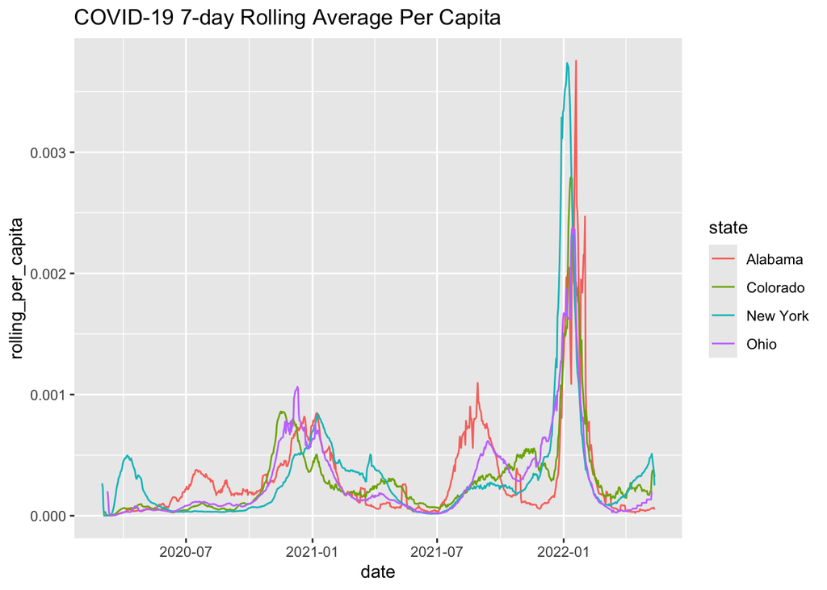

```r
ggplot(state_covid_per_capita, aes(x = date, y = rolling_per_capita, color = state)) +
  geom_line() +
  labs(title = "COVID-19 7-day Rolling Average Per Capita")
```

Briefly describe the influence scaling by population had on the analysis? Does it make some states look better? Some worse? How so?

Scaling by population impacts how the data is understood. This is because these states have very different population sizes, and we are counting cases per capita. States with larger populations may appear to have less cases than the states with smaller populations. This can potentially cause states with smaller populations to be seen as worse, even though they may have less total cases.

Question 7:

```r
library(readr)

county_centroids <- read_csv('https://raw.githubusercontent.com/mikejohnson51/csu-ess-330/refs/heads/main/resources/county-centroids.csv')
```

```r
covid_with_locations <- covid %>%
  mutate(fips = as.character(fips)) %>%
  left_join(county_centroids, by = "fips")
```

```r
covid_with_locations$date <- as.Date(covid_with_locations$date)
```

```r
covid_weighted_mean <- covid_with_locations %>%
  group_by(date) %>%
  reframe(
    weighted_lat = sum(LAT * cases, na.rm = TRUE) / sum(cases, na.rm = TRUE),
    weighted_lon = sum(LON * cases, na.rm = TRUE) / sum(cases, na.rm = TRUE),
    total_cases = sum(cases, na.rm = TRUE),
    month = format(date, "%m")
  ) %>%
  ungroup()
```

```r
options(repos = c(CRAN = "https://cloud.r-project.org/"))
```

```r
library(ggplot2)
library(dplyr)
library(maps)
```

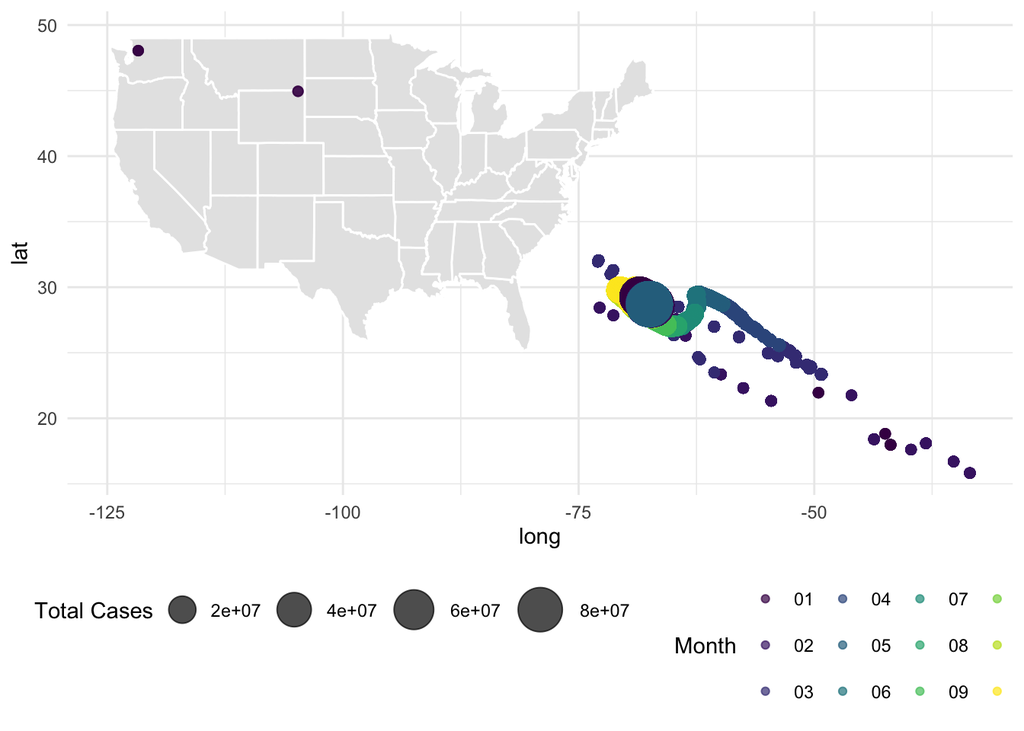

```r
ggplot() +
  borders("state", fill = "gray90", colour = "white") +
  geom_point(data = covid_weighted_mean, aes(x = weighted_lon, y = weighted_lat, size = total_cases, color = month), alpha = 0.7) +
  scale_size_continuous(name = "Total Cases", range = c(2, 10)) +
  scale_color_viridis_d(name = "Month") +
  theme_minimal() +
  theme(legend.position = "bottom")
```